# CaseCosMx: Annotate Non-small cell lung cancer CosMx samples using 4 scRNA-seq references

# Preparation

Load necessary packages.

```r
# Install latest version of PhiSpace from github
suppressMessages(devtools::install_github("jiadongm/PhiSpace/pkg"))

# Load packages and predefined quantities
suppressPackageStartupMessages(library(PhiSpace))
suppressPackageStartupMessages(library(ggplot2))
suppressPackageStartupMessages(library(dplyr))
suppressPackageStartupMessages(library(tidyr))
suppressPackageStartupMessages(library(magrittr))
suppressPackageStartupMessages(library(scuttle))
suppressPackageStartupMessages(library(scran))
suppressPackageStartupMessages(library(ggpubr))
suppressPackageStartupMessages(library(qs)) # quick read and write of R objects

suppressPackageStartupMessages(library(ComplexHeatmap))
suppressPackageStartupMessages(library(seriation))


source("utils.R")
dat_dir <- "/data/projects/punim0613/JiaDong/PhiSpace/"

PhiAssay <- "log1p"
```

In this case study we downloaded 4 scRNA-seq reference datasets from healthy and fibrotic lungs, each containing cells from a different lineage (immune, epithelial, endothelial and mesenchymal):

Vannan, A., Lyu, R., Williams, A. L., Negretti, N. M., Mee, E. D., Hirsh, J., … Banovich, N. E. (2023). Image-based spatial transcriptomics identifies molecular niche dysregulation associated with distal lung remodeling in pulmonary fibrosis. bioRxiv : The Preprint Server for Biology. Retrieved from https://doi.org/10.1101/2023.12.15.571954

The query dataset contained CosMx NSCLC lung samples, as described in:

He, S., Bhatt, R., Brown, C., Brown, E. A., Buhr, D. L., Chantranuvatana, K., … Beechem, J. M. (2022). High-plex imaging of RNA and proteins at subcellular resolution in fixed tissue by spatial molecular imaging. Nature Biotechnology, 40(12), 1794–1806.

Load 4 refernce datasets from 4 lineages as a list.

```r
YtrainName <- c("manual_annotation_1")
ref_list <- lapply(
  c("immune", "epithelial", "endothelial", "mesenchymal"),
  function(lineage){

    qread(paste0(dat_dir, "data/LungFibrosis/scRNA-seq/", lineage, "_sce.qs"))
  }
)
names(ref_list) <- c("immune", "epithelial", "endothelial", "mesenchymal")
```

Process query datasets and load annotations. See `runPhiSpace4Refs.R` for details.

```r
tissueNames <- tissueNames_CosMx
query_list <- qread(paste0(dat_dir, "data/CosMx_lung/SCE_obj/allTissue_SCE.qs"))
PhiResPath <- paste0(
  dat_dir, "output/Case3/CosMxAllLungsPhiRes4Refs_", PhiAssay, ".qs"
)
sc_list <- qread(PhiResPath)
for(ii in 1:length(tissueNames)){
  tissueName <- tissueNames[ii]
  query <- query_list[[tissueName]]
  sc4Refs <- lapply(sc_list, function(x) x[[tissueName]])
  reducedDim(query, "PhiSpace") <- Reduce(cbind, sc4Refs)
  query_list[[ii]] <- query
}
# Simplify cell type names
originalNames <- simpleNames <- colnames(reducedDim(query_list[[1]], "PhiSpace"))
simpleNames[c(2, 4, 9, 10, 12, 18, 21, 23, 24, 25, 26, 43)] <- c(
  "MoMacroph(immune)", "InflamMono(immune)",  "AlveolarMacroph(immune)",
  "ProlifImm(immune)", "InterstMacroph(immune)", "ProlifEpi(epithelial)",
  "SecretSCGB3A2+(epithelial)", "TransAT2(epithelial)", "SecretSCGB1A1+/MUC5B+(epithelial)",
  "SecretSCGB1A1+/SCGB3A2+(epithelial)", "DiffCiliated(epithelial)", "MyoFB Act(mesenchymal)"
)
# cbind(originalNames, simpleNames)
for(ii in 1:length(query_list)){
  query <- query_list[[ii]]
  colnames(reducedDim(query, "PhiSpace")) <- simpleNames
  query_list[[ii]] <- query
}
```

# Analyses

```r
for(ii in 1:length(tissueNames)){
  tissueName <- tissueNames[ii]
  outPlots <- tempSavePlots(
    sce = query_list[[tissueName]],
    tissueName = tissueName,
    freeColScale = T, censQuant = 0.5
  )
}
```

Clustering cell-like objects based on their PhiSpace cell type scores by k-means.

```r
LungName <- "Lung5_Rep1"
query <- query_list[[LungName]]
clustResPath <- paste0(dat_dir, "output/Case3/Lung5_Rep1_PhiClusts4Refs.qs")
if(!file.exists(clustResPath)){

  PhiPCRes <- getPC(
    reducedDim(query, "PhiSpace"), ncomp = ncol(reducedDim(query, "PhiSpace")) - 1
  )
  plot(1-PhiPCRes$accuProps)
  mat2clust <- PhiPCRes$scores[,1:25]
    set.seed(94863)
  clust_res <- kmeans(
    mat2clust, centers = 9, iter.max = 200L, nstart = 50
  )
  qsave(clust_res, clustResPath)
} else {
  clust_res <- qread(clustResPath)
}
query$PhiClust <- as.character(clust_res$cluster)
tempClustCols <- c(
  "1" = "#E5D8BD", "2" = "#CCEBC5", "3" = "#FED9A6", "4" = "#B3CDE3",
  "5" = "gray", "6" = "#FBB4AE", "7" =  "#DECBE4", "8" =  "#FFFFCC", "9" = "gray50"
)
p <- VizSpatial(
  query, x_coord = "sdimx", y_coord = "sdimy", groupBy = "PhiClust", ptSize = 0.3
) +
  # scale_colour_brewer(palette = "Set1") +
  scale_colour_manual(values = tempClustCols) +
  guides(
    colour = guide_legend(
      override.aes = list(size = 2), nrow = 1
    )
  ) +
  theme(
    legend.title = element_text(face = "bold"),
    legend.position = "top",
    legend.key.spacing = unit(0, "pt")
  ) +
  labs(colour = "")
p
ggsave(
  "figs/clusts/PhiClust.png",
  p + theme(legend.position = "none"),
  width = 2.5, height = 2.5
)
```

```r
png(
  paste0("figs/clusts/PhiClust_leg.png"),
  width = 4, height = 0.4, units = "in", res = 300
)
op <- par(mar = rep(0, 4))
grid::grid.draw(get_legend(p))
```

[figure not shown]

```r
par(op)
dev.off()
```

Compare to clustering cell-like objects based on their gene expression.

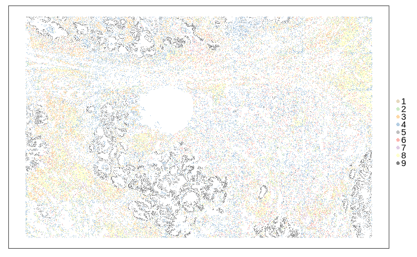

```r
clustResPhi <- clust_res
clustResPath <- paste0(dat_dir, "output/Case3/Lung5_Rep1_OmicsClusts4Refs.qs")
if(!file.exists(clustResPath)){

  mat2clust <- getPC(
    t(assay(query, "log1p")), ncomp = 20
  )$scores
  set.seed(94858)
  clust_res <- kmeans(
    mat2clust, centers = 9, iter.max = 200L, nstart = 50
  )
  qsave(clust_res, clustResPath)
} else {
  clust_res <- qread(clustResPath)
}
query$GenClust <- align_clusters(as.character(clust_res$cluster), query$PhiClust)
p <- VizSpatial(
  query, x_coord = "sdimx", y_coord = "sdimy", groupBy = "GenClust", ptSize = 0.3
) +
  # scale_colour_brewer(palette = "Set1") +
  scale_colour_manual(values = tempClustCols) +
  guides(
    colour = guide_legend(
      override.aes = list(size = 2)
    )
  ) +
  theme(
    legend.title = element_text(face = "bold"),
    legend.position = "right",
    legend.key.spacing = unit(0, "pt")
  ) +
  labs(colour = "")
p
ggsave(
  "figs/clusts/OmicsClust.png",
  p + theme(legend.position = "none"),
  width = 2.5, height = 2.5
)
```

Plotting spatial domains annotated by data generators.

```r
for(ii in 1:length(tissueNames)){

  tissueName <- tissueNames[ii]
  query <- query_list[[tissueName]]
  p <- VizSpatial(
    query, "sdimx", "sdimy",
    ptSize = 0.5,
    groupBy = "niche",
    legend.position = "bottom"
  ) +
    scale_colour_manual(values = nicheCol) +
    guides(
      colour = guide_legend(
        override.aes = list(size = 2),
        nrow = 3
      )
    ) +
    theme(
      legend.box.spacing = unit(0, "cm"),
      legend.key.size = unit(0, "cm")
    )
  ggsave(
    paste0("figs/niches/originalNiche_", tissueName, ".png"),
    p,
    width = 5, height = 5
  )
}
```

Calculate cell type divergence for each cell-like object and visualise.

```r
query$divergence <- apply(
  reducedDim(query, "PhiSpace"), 1, quantile, prob = 0.75
)
p <- VizSpatial(query, "sdimx", "sdimy", ptSize = 0.3, groupBy = "divergence", reOrder = T, fsize = 6) +
  scale_colour_stepsn(colours = MATLAB_cols, values = c(0, 0.25, 0.5, 0.75, 1)) +
  theme(legend.position = "bottom")
png(
  paste0("figs/divergence_leg.png"),
  width = 2, height = 0.4, units = "in", res = 300
)
op <- par(mar = rep(0, 4))
grid::grid.draw(get_legend(p))
par(op)
dev.off()
```

```r
ggsave("figs/divergence.png", p + theme(legend.position = "none"), width = 2, height = 2)
```

Viz niche specific divergence

```r
pBox <- colData(query) %>% as.data.frame() %>%
  ggplot(aes(x = PhiClust, y = divergence)) +
  geom_boxplot(aes(fill = PhiClust), outlier.size = 0.5, linewidth = 0.1, outlier.stroke = 0) +
  theme_bw(base_size = 6) +
  theme(
    legend.position = "none"
  ) + scale_fill_manual(values = tempClustCols) +
  xlab("PhiSpace Clusters") + ylab("Divergence")
ggsave("figs/clusts/divergence.png", pBox, width = 1, height = 2)

nicheClust <- table(query$niche, query$PhiClust) %>% t %>% as.data.frame.matrix()
pNicheClust <- nicheClust %>% as.data.frame() %>%
  mutate(
    cluster = rownames(nicheClust) %>% as.factor()
  ) %>% pivot_longer(
  ! cluster, names_to = "niche", values_to = "counts"
) %>% ggplot(aes(cluster, counts)) + geom_col(aes(fill = niche), position = "fill") +
  scale_fill_manual(values = nicheCol) +
  theme_bw(base_size = 6) +
  theme(
    legend.position = "none"
  ) +
  xlab("PhiSpace clusters") + ylab("Proportions")
ggsave("figs/clusts/nicheClust.png", pNicheClust, width = 1, height = 2)
```

Look at clusters 5 and 9 in detail.

```r
clustIdx = 6
topK = 10
topBoxes <- c()
for(clustIdx in c(5, 9)){
  plotDat <- reducedDim(query, "PhiSpace") %>% as.data.frame() %>%
    mutate(clusters = colData(query)[,"PhiClust"]) %>%
    pivot_longer(!clusters, names_to = "cellType", values_to = "scores") %>%
    filter(clusters == clustIdx) %>%
    group_by(cellType) %>% mutate(MedianValue = median(scores)) %>%
    ungroup() %>% mutate(cellType = reorder(cellType, MedianValue))
  topBox <- plotDat %>%
      distinct(cellType, MedianValue) %>%
      arrange(desc(MedianValue)) %>%
      slice(1:topK) %>%
      pull(cellType) %>%
    as.character()
  topBoxes <- c(topBoxes, topBox)
}
unique(topBoxes)
```

```
 [1] "Mesothelial(mesenchymal)"          "SecretSCGB1A1+/MUC5B+(epithelial)" "TransAT2(epithelial)"              "Basal(epithelial)"
 [5] "KRT5-/KRT17+(epithelial)"          "Lymphatic(endothelial)"            "Adventitial FB(mesenchymal)"       "aCap(endothelial)"
 [9] "SecretSCGB3A2+(epithelial)"        "InterstMacroph(immune)"            "Inflamed(endothelial)"
```

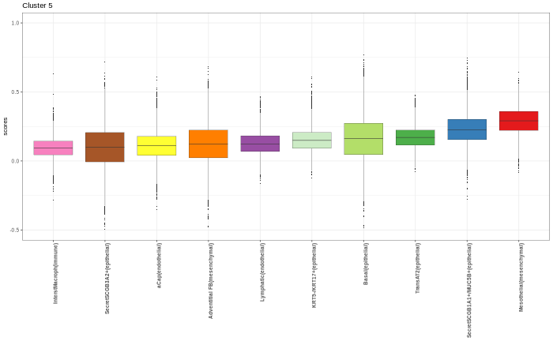

```r
tempCTypeCols <- c(
  "Mesothelial(mesenchymal)" = "#E41A1C", "SecretSCGB1A1+/MUC5B+(epithelial)" = "#377EB8",
  "TransAT2(epithelial)" = "#4DAF4A", "Basal(epithelial)" = "#B3DE69",
  "KRT5-/KRT17+(epithelial)" = "#CCEBC5", "Lymphatic(endothelial)"  = "#984EA3",
  "Adventitial FB(mesenchymal)" = "#FF7F00", "aCap(endothelial)" = "#FFFF33",
  "SecretSCGB3A2+(epithelial)" = "#A65628", "InterstMacroph(immune)" = "#F781BF",
  "Inflamed(endothelial)" = "#FB8072"
)
p1 <- tempClustSignature(query, "PhiClust", clustIdx = 5, fsize = 6) +
  theme(
    legend.position = "none",
    axis.text.x = element_text(face = "bold"), axis.title.x = element_blank()
  )
p2 <- tempClustSignature(query, "PhiClust", clustIdx = 9, fsize = 6) +
  theme(
    legend.position = "none",
    axis.text.x = element_text(face = "bold"), axis.title.x = element_blank()
  )
p1; p2
```

[figure not shown]

```r
ggsave("figs/clusts/clust5.png", p1, width = 1.5, height = 2.5)
ggsave("figs/clusts/clust9.png", p2, width = 1.5, height = 2.5)
```

# Multi-sample analysis

Enriched cell types of individual tumours.

```r
tumourSig <- tumourSig_indiv  <- regCoef_list <- regCoefIndiv_list <-  vector("list", length(tissueNames)) %>%
  `names<-`(tissueNames)
#Individual tumours
for(ii in 1:length(tissueNames)){

  tissueName <- tissueNames[ii]
  query <- query_list[[tissueName]]
  Y <- codeY(query, "cell_type")
  X <- reducedDims(query)[["PhiSpace"]]
  ncomp <- ncol(Y) - 1
  pls_res <- mvr(X, Y, ncomp = ncomp, method = "PLS")
  regCoef <- pls_res$coefficients[,,ncomp]
  regCoefIndiv_list[[ii]] <- regCoef
  selectedPheno <- selectFeat(regCoef, nfeat = 5, absVal = F)
  tumourSig_indiv[[ii]] <- selectedPheno$orderedFeatMat[,grepl("tumor", selectedPheno$orderedFeatMat %>% colnames)]
}
# Niche
for(ii in 1:length(tissueNames)){

  tissueName <- tissueNames[ii]
  query <- query_list[[tissueName]]
  Y <- codeY(query, "niche")
  X <- reducedDims(query)[["PhiSpace"]]
  ncomp <- ncol(Y) - 1
  pls_res <- mvr(X, Y, ncomp = ncomp, method = "PLS")
  regCoef <- pls_res$coefficients[,,ncomp]
  regCoef_list[[ii]] <- regCoef
  selectedPheno <- selectFeat(regCoef, nfeat = 5, absVal = F)
  tumourSig[[ii]] <- selectedPheno$orderedFeatMat[,"tumor interior"]
}
```

Print top 5 markers of each niche, in different tissues

```r
nMks <- 5
nicheNames <- lapply(
  regCoef_list, function(x) colnames(x)
) %>% unlist() %>% unique() %>% sort()
nicheMkTab <- lapply(
  regCoef_list,
  function(x){

    featTab <- selectFeat(x, absVal = F)$orderedFeat[1:nMks,]
    commonNiche <- intersect(colnames(featTab), nicheNames)
    out <- matrix(NA, nrow = nMks, ncol = length(nicheNames)) %>%
      `colnames<-`(nicheNames)
    out[,commonNiche] <- featTab[,commonNiche]
    return(out)
  }
)
xtable::xtable(nicheMkTab[[1]], type = "latex")
```

```
% latex table generated in R 4.4.0 by xtable 1.8-4 package
% Mon Dec 16 09:41:52 2024
\begin{table}[ht]
\centering
\begin{tabular}{rlllllllll}
  \hline
 & immune & lymphoid structure & macrophages & myeloid-enriched stroma & neutrophils & plasmablast-enriched stroma & stroma & tumor interior & tumor-stroma boundary \\
  \hline
1 & CD4(immune) & CD4(immune) & aCap(endothelial) & aCap(endothelial) & SecretSCGB1A1+/MUC5B+(epithelial) & Plasma(immune) & InflamMono(immune) & Mesothelial(mesenchymal) & MyoFB Act(mesenchymal) \\
  2 & Ciliated(epithelial) & cDC1(immune) & InterstMacroph(immune) & InterstMacroph(immune) & MyoFB Act(mesenchymal) & pDC(immune) & MyoFB Act(mesenchymal) & Basal(epithelial) & KRT5-/KRT17+(epithelial) \\
  3 & gCap(endothelial) & B cells(immune) & Pericyte(mesenchymal) & Pericyte(mesenchymal) & AlveolarMacroph(immune) & MyoFB Act(mesenchymal) & Venule(endothelial) & SecretSCGB1A1+/MUC5B+(epithelial) & TransAT2(epithelial) \\
  4 & PLIN2+ FB(mesenchymal) & SecretSCGB3A2+(epithelial) & MoMacroph(immune) & MoMacroph(immune) & MyoFB(mesenchymal) & B cells(immune) & Alveolar FB(mesenchymal) & SecretSCGB3A2+(epithelial) & AlveolarMacroph(immune) \\
  5 & B cells(immune) & Systemic venous(endothelial) & moDC(immune) & gCap(endothelial) & Ciliated(epithelial) & Ciliated(epithelial) & DiffCiliated(epithelial) & AlveolarMacroph(immune) & ProlifImm(immune) \\
   \hline
\end{tabular}
\end{table}
```

```r
tab <- selectFeat(regCoef_list$Lung5_Rep1, absVal = F)$orderedFeat[1:nMks,]
knitr::kable(tab)
```

| plasmablast-enriched stroma | stroma | lymphoid structure | tumor-stroma boundary | immune | myeloid-enriched stroma | tumor interior | neutrophils | macrophages |
| --- | --- | --- | --- | --- | --- | --- | --- | --- |
| Plasma(immune) | InflamMono(immune) | CD4(immune) | MyoFB Act(mesenchymal) | CD4(immune) | aCap(endothelial) | Mesothelial(mesenchymal) | SecretSCGB1A1+/MUC5B+(epithelial) | aCap(endothelial) |
| pDC(immune) | MyoFB Act(mesenchymal) | cDC1(immune) | KRT5-/KRT17+(epithelial) | Ciliated(epithelial) | InterstMacroph(immune) | Basal(epithelial) | MyoFB Act(mesenchymal) | InterstMacroph(immune) |
| MyoFB Act(mesenchymal) | Venule(endothelial) | B cells(immune) | TransAT2(epithelial) | gCap(endothelial) | Pericyte(mesenchymal) | SecretSCGB1A1+/MUC5B+(epithelial) | AlveolarMacroph(immune) | Pericyte(mesenchymal) |
| B cells(immune) | Alveolar FB(mesenchymal) | SecretSCGB3A2+(epithelial) | AlveolarMacroph(immune) | PLIN2+ FB(mesenchymal) | MoMacroph(immune) | SecretSCGB3A2+(epithelial) | MyoFB(mesenchymal) | MoMacroph(immune) |
| Ciliated(epithelial) | DiffCiliated(epithelial) | Systemic venous(endothelial) | ProlifImm(immune) | B cells(immune) | gCap(endothelial) | AlveolarMacroph(immune) | Ciliated(epithelial) | moDC(immune) |

```r
write.csv(tab, "figs/signatures/Lung5_Rep1_tumour.csv")
```

Enriched cell types of individual tumours.

```r
tumTab <- do.call("cbind", tumourSig)[1:10,]
knitr::kable(tumTab)
```

| Lung5_Rep1 | Lung5_Rep2 | Lung5_Rep3 | Lung6 | Lung9_Rep1 | Lung9_Rep2 | Lung12 | Lung13 |
| --- | --- | --- | --- | --- | --- | --- | --- |
| Mesothelial(mesenchymal) | Mesothelial(mesenchymal) | Mesothelial(mesenchymal) | Basal(epithelial) | Mesothelial(mesenchymal) | Mesothelial(mesenchymal) | Adventitial FB(mesenchymal) | Mesothelial(mesenchymal) |
| Basal(epithelial) | SecretSCGB1A1+/MUC5B+(epithelial) | Basal(epithelial) | MyoFB Act(mesenchymal) | Mast(immune) | CD4(immune) | Mesothelial(mesenchymal) | MoMacroph(immune) |
| SecretSCGB1A1+/MUC5B+(epithelial) | Basal(epithelial) | SecretSCGB3A2+(epithelial) | MyoFB(mesenchymal) | InterstMacroph(immune) | Mast(immune) | SecretSCGB1A1+/MUC5B+(epithelial) | AlveolarMacroph(immune) |
| SecretSCGB3A2+(epithelial) | SecretSCGB3A2+(epithelial) | SecretSCGB1A1+/MUC5B+(epithelial) | PNEC(epithelial) | CD4(immune) | Systemic venous(endothelial) | AlveolarMacroph(immune) | SecretSCGB1A1+/MUC5B+(epithelial) |
| AlveolarMacroph(immune) | TransAT2(epithelial) | Adventitial FB(mesenchymal) | Mast(immune) | Arteriole(endothelial) | Lymphatic(endothelial) | aCap(endothelial) | Lymphatic(endothelial) |
| Adventitial FB(mesenchymal) | AlveolarMacroph(immune) | AlveolarMacroph(immune) | NK(immune) | Systemic venous(endothelial) | Pericyte(mesenchymal) | AT1(epithelial) | NK(immune) |
| aCap(endothelial) | KRT5-/KRT17+(epithelial) | SMC(mesenchymal) | Systemic venous(endothelial) | Ciliated(epithelial) | Arteriole(endothelial) | SMC(mesenchymal) | TransAT2(epithelial) |
| TransAT2(epithelial) | Adventitial FB(mesenchymal) | TransAT2(epithelial) | KRT5-/KRT17+(epithelial) | MyoFB Act(mesenchymal) | AT2(epithelial) | Monocyte(immune) | Adventitial FB(mesenchymal) |
| InterstMacroph(immune) | aCap(endothelial) | aCap(endothelial) | InflamMono(immune) | Lymphatic(endothelial) | SecretSCGB3A2+(epithelial) | TransAT2(epithelial) | pDC(immune) |
| KRT5-/KRT17+(epithelial) | SMC(mesenchymal) | InterstMacroph(immune) | Plasma(immune) | Plasma(immune) | ProlifEpi(epithelial) | AT2(epithelial) | Plasma(immune) |

```r
# xtable::xtable(tumTab, type = "latex")
write.csv(tumTab, "figs/signatures/allTumours.csv")
```

Hypothesis: combinations of cell states in cancer cells are very unique, enough to distinguish them from other niche. First check if correlation matrices (vectorised) indeed cluster according to niche label.

Co-presence matrix of tumour interior niche of Lung5_Rep1, as an example.

```r
tissueName <- "Lung5_Rep1"
# query <- query_list[[tissueName]]
x <- "tumor interior"
qu_sub <- query[,query$niche==x]
corMat <- cor(
  reducedDims(qu_sub)[["PhiSpace"]]
)
cVars <- colVars(corMat)
selectedTypes <- names(cVars)[rank(-cVars) <= 25]
corMat <- corMat[selectedTypes, selectedTypes]
hm <- tempHeatmap(
  corMat, binColour = F, fsize = 6, useSeriate = T
)
hm
png(paste0("figs/specialCases/", tissueName, "_", gsub(" ", "_", x), "_heatmap.png"),
    width = 3.1, height = 2, units = "in", res = 300)
draw(hm)
dev.off()
```

[output not shown]

Compute all cell type co-presence matrices and vectorise them for PCA.

```r
corMatVec <- lapply(
  1:length(tissueNames),
  function(ii){

    tissueName <- tissueNames[ii]
    query <- query_list[[tissueName]]
    tempNicheNames <- unique(query$niche)
    # List of correlation matrices (corMats)
    corMat_list <- lapply(
      tempNicheNames,
      function(x){

        nicheName <- x
        corMat <- cor(
          reducedDim(query[,query$niche==nicheName], "PhiSpace")
        )
        return(corMat)
      }
    )
    names(corMat_list) <- tempNicheNames
    # Labels for entries in each corMat
    cTypeCombo <- outer(
          rownames(corMat_list[[1]]), colnames(corMat_list[[1]]),
          function(x, y) paste0(x, "<->", y)
        )
    # Vectorise corMats
    corMatVec <- sapply(
      corMat_list,
      function(x) as.vector(x[lower.tri(x)])
    ) %>%
      `colnames<-`(
        paste0(tempNicheNames, "_", tissueName)
      ) %>%
      `rownames<-`(
        cTypeCombo[lower.tri(cTypeCombo)]
      ) %>%
      t()
    corMatVec <- corMatVec %>%
      as.data.frame() %>%
      mutate(
        niche = tempNicheNames,
        sample = rep(tissueName, nrow(corMatVec))
      )
    return(corMatVec)
  }
)
corMatVec <- do.call(rbind, corMatVec)
# Delete niches with fewer than 50 cells
minNicheCells <- 50
nicheTabs <- lapply(
  1:length(query_list),
  function(x){

    tissueName <- names(query_list)[x]
    out <- table(query_list[[x]]$niche)
    names(out) <- paste0(names(out), "_", tissueName)
    return(out)
  }
)
nPerNiche <- do.call("c", nicheTabs)
corMatVec <- corMatVec[names(nPerNiche)[nPerNiche >= minNicheCells], ]
```

```r
# Loading
p1_load <- loadBarplot(pca_res, "comp1", showInt = T, nfeat = 30, fsize = 6)
```

[output not shown]

DWD separating cancer from non-cancer niches. We use the `kerndwd` implementation of DWD:

```r
suppressPackageStartupMessages(library(kerndwd))
# Define binary class labels
nicheBinary <- as.numeric(corMatVec$niche %in% c("tumor interior", "tumor-stroma boundary"))
nicheBinary[nicheBinary == 0] <- -1
nicheBinaryByName <- rep("Non-cancer niches", length(nicheBinary))
nicheBinaryByName[nicheBinary == 1] <- "Cancer niches"
# Centre input matrix
X = corMatVec %>% select(!c(niche, sample)) %>% as.matrix
X_cent <- scale(X, center = T, scale = F)
# Tune DWD
set.seed(012361)
lambda = 10^(seq(3, -3, length.out=50))
kern = vanilladot()
cv_res = cv.kerndwd(X_cent, nicheBinary, kern, qval=1, lambda=lambda, eps=1e-5, maxit=1e5)
da_res = kerndwd(X_cent, nicheBinary, kern, qval=1, lambda=cv_res$lambda.min, eps=1e-5, maxit=1e5)
# Calculate DWD scores and loadings
A <- da_res$alpha[-1,,drop=F]
dwdLoad <- crossprod(X_cent, A) %>% `colnames<-`("comp1") # worked out by looking at predict.dwd
rownames(dwdLoad) <- gsub("\\([^\\)]*\\)", "", rownames(dwdLoad))
dwdScore <- predict.kerndwd(da_res, kern, X_cent, X_cent, "link") %>% `colnames<-`("comp1")
# dwd_res <- list(
#   scores = dwdScore %>% as.data.frame(), loadings = dwdLoad %>% as.data.frame()
# )
```

```r
png(
  paste0("figs/multiSample/nicheDWD_densPlot_legend.png"),
  width = 2, height = 0.4, units = "in", res = 300
)
op <- par(mar = rep(0, 4))
grid::grid.draw(get_legend(p_dens))
par(op)
dev.off()
```